# BF_Finals

Srishti Patil

2024-12-09

#### Import Data

```r
library(forecast)
```

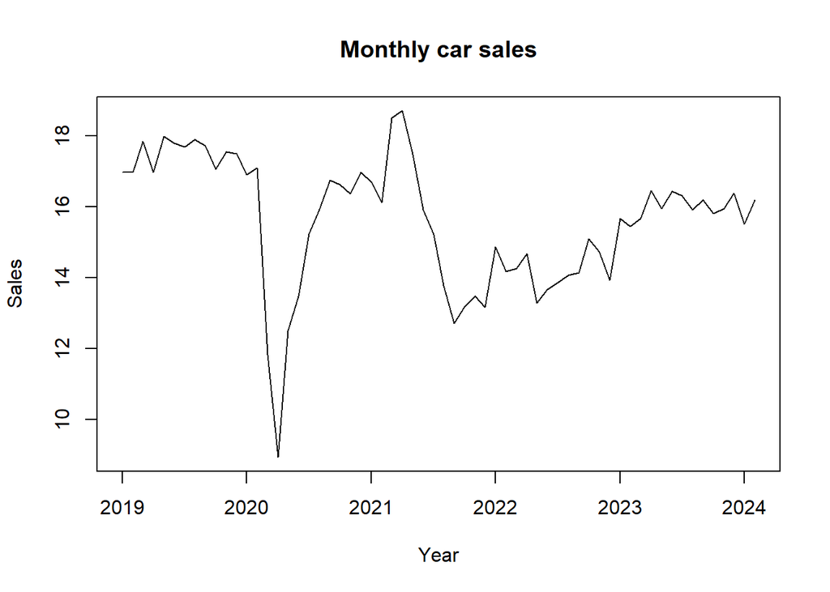

```r
library(ggplot2)
data <- read.csv("C:\\Users\\Srishti\\Desktop\\FALL24\\BF\\Finals\\TOTALSA.csv")
dataTimeSerie <- ts(data$Sales, start = c(2019,1) , end = c(2024,2), frequency = 12)
plot(dataTimeSerie, main='Monthly car sales', xlab ='Year', ylab='Sales')
```

```r
windowTS <- window(dataTimeSerie, start = c(2022,1))
```

####Plot and Inference #• Show a time series plot. #• Please summaries your observations of the times series plot

The time series exhibits a general upward trend, indicating that the sales of cars are increasing over the observed time period. There are periodic fluctuations or irregular movements in the data, but they remain relatively small compared to the overall trend.

The ACF indicates strong positive autocorrelations at initial lags, which gradually decay and alternate between positive and negative. This suggests a possible trend or seasonality in the time series.

####Central Tendency #• What are the min, max, mean, median, 1st and 3rd Quartile values of the times series? #• Show the box plot. #• Can you summarize your observation about the time series from the summary stats and box plot?

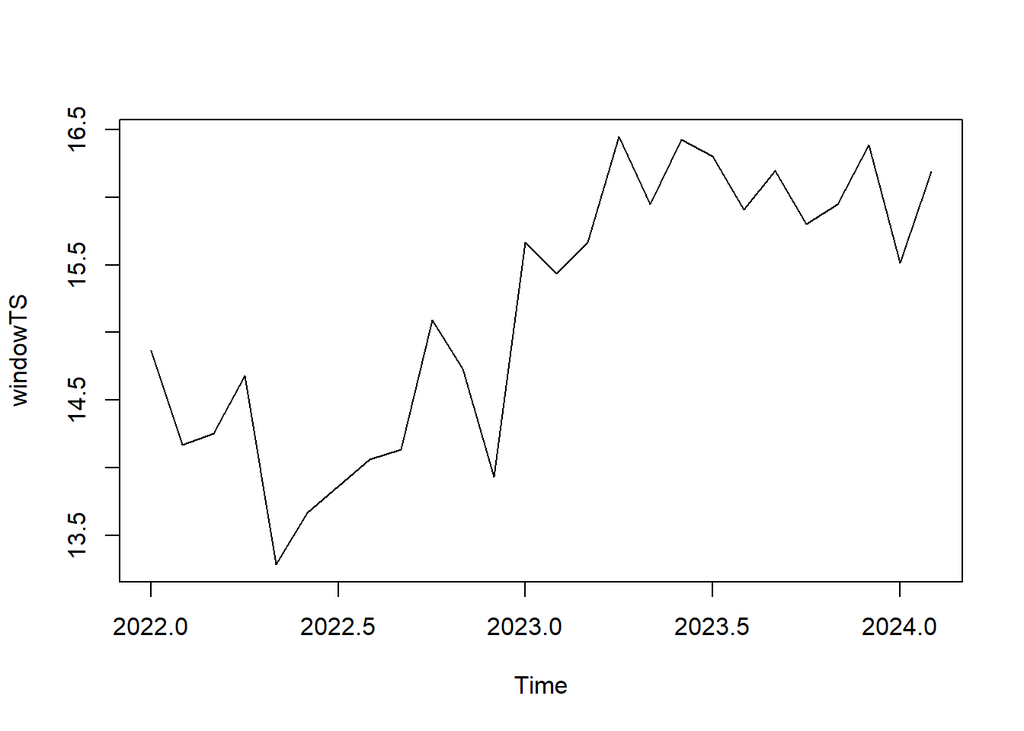

```r
plot(windowTS)
```

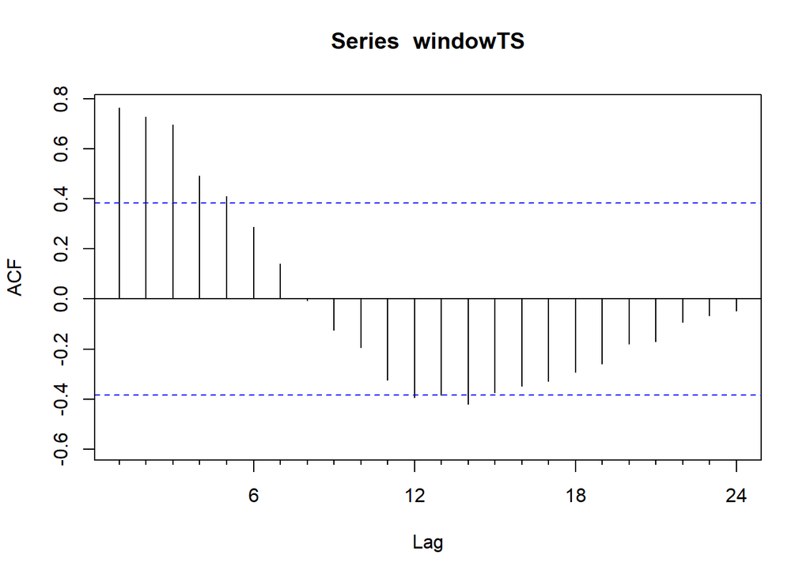

```r
Acf(windowTS)
```

```r
summary(windowTS)
```

```
##    Min. 1st Qu.  Median    Mean 3rd Qu.    Max.
##   13.29   14.19   15.47   15.18   15.95   16.45
```

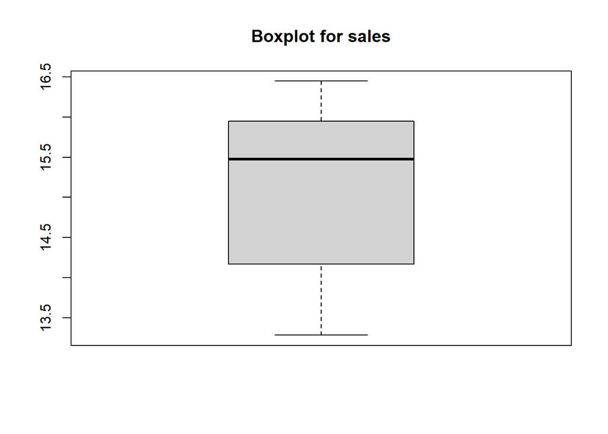

```r
boxplot(windowTS, main ="Boxplot for sales")
```

## Decomposition

#### Plot the decomposition of the time series.

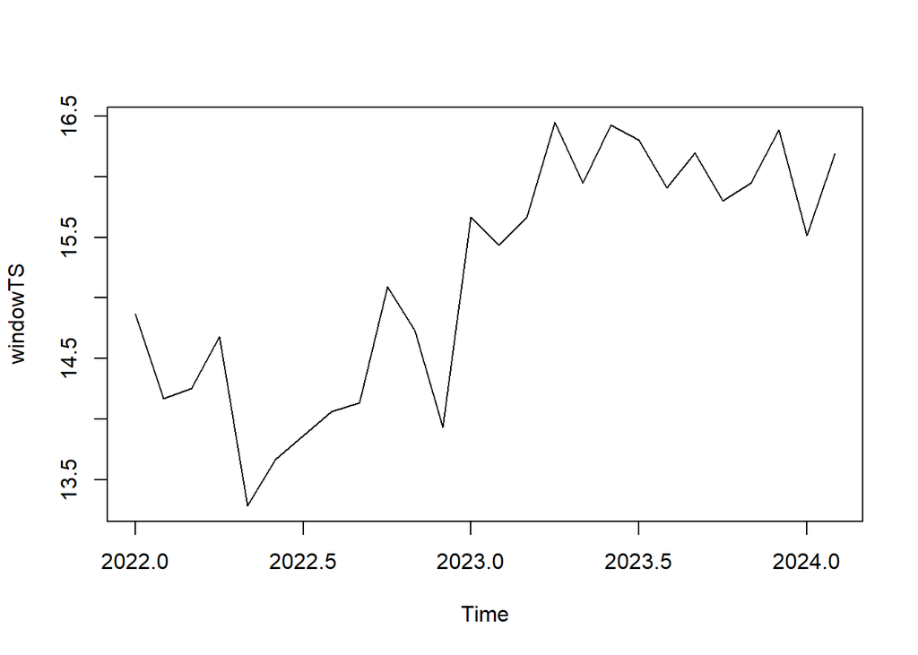

```r
decompositionTs <- decompose(windowTS)
plot(windowTS)
```

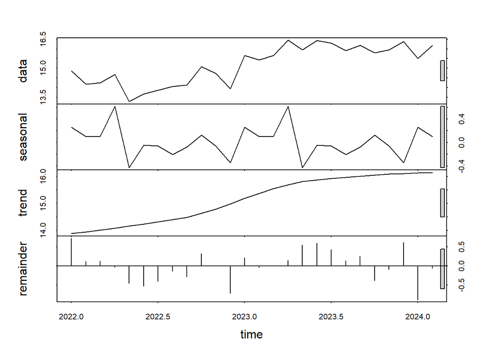

```r
stlDecomp <- stl(windowTS, s.window = "periodic" )
plot(stlDecomp)
```

#### Is the time series seasonal? YES, as per the above grapth the timeseries is seasonal. #### Is the decomposition additive or multiplicative?

```r
decompositionTs$type
```

```
## [1] "additive"
```

The decomposition type is Additive as the changes stay similay over time ie their size doesnt change acccording to the trend.

#### If seasonal, what are the values of the seasonal monthly indices?

```r
seasonalIndices <- stlDecomp$time.series[,"seasonal"]
print(seasonalIndices)
```

```
##              Jan         Feb         Mar         Apr         May         Jun
## 2022  0.25666991  0.09763921  0.10858197  0.61612963 -0.42582271 -0.04334869
## 2023  0.25666991  0.09763921  0.10858197  0.61612963 -0.42582271 -0.04334869
## 2024  0.25666991  0.09763921
##              Jul         Aug         Sep         Oct         Nov         Dec
## 2022 -0.05637468 -0.20412335 -0.07587202  0.12676502 -0.05709795 -0.34314621
## 2023 -0.05637468 -0.20412335 -0.07587202  0.12676502 -0.05709795 -0.34314621
## 2024
```

#### For which month is the time series value high, and for which month is it low?

```r
highest <- which.max(seasonalIndices)
lowest <- which.min(seasonalIndices)
print(paste("highest seasonal value month:", highest))
```

```
## [1] "highest seasonal value month: 4"
```

```r
print(paste("lowest seasonal value month:", lowest))
```

```
## [1] "lowest seasonal value month: 5"
```

#### Show the plot for time series adjusted for seasonality. Overlay this with the line for actuals? Does seasonality have big fluctuations in the value of time series?

```r
seasadj(stlDecomp)
```

```
##           Jan      Feb      Mar      Apr      May      Jun      Jul      Aug
## 2022 14.60933 14.07036 14.14442 14.06487 13.71182 13.71235 13.92337 14.26812
## 2023 15.40833 15.33636 15.55942 15.82987 16.37382 16.47135 16.35837 16.11312
## 2024 15.25633 16.09336
##           Sep      Oct      Nov      Dec
## 2022 14.21187 14.96423 14.79010 14.27815
## 2023 16.26887 15.67223 16.00210 16.72915
## 2024
```

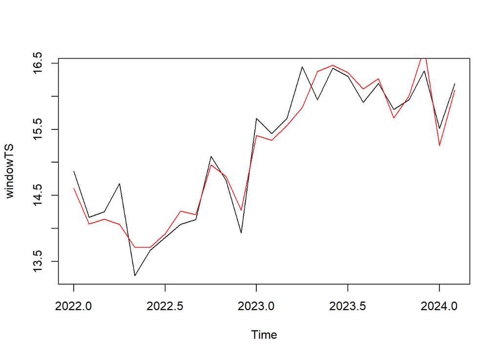

```r
plot(windowTS)
lines(seasadj(stlDecomp), col ="Red")
```

The red line is the seasonallly adjusted timeseries. We can see it is smoothed out. Seasonal adjustments doesnt have big fluctions with the value of timeseries.

# Naïve Method

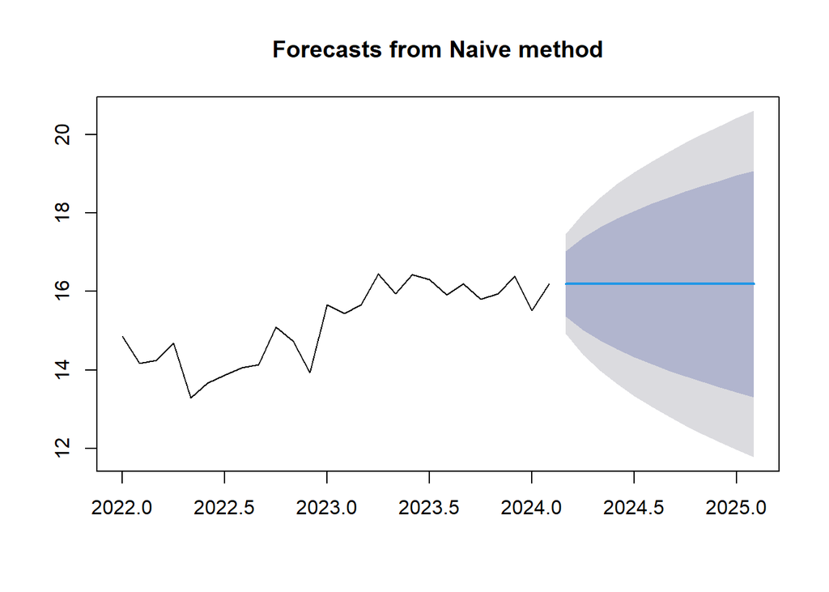

```r
naiveForecast <- naive(windowTS, h = 12)
plot(naiveForecast)
```

### Perform Residual Analysis for this technique. #### Do a plot of residuals. What does the plot indicate?

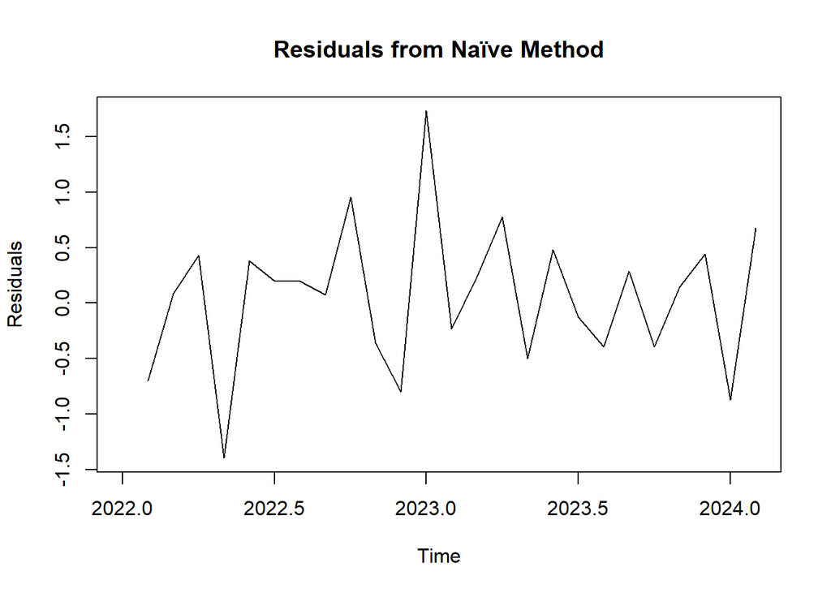

```r
plot(residuals(naiveForecast) , main = "Residuals from Naïve Method", ylab = "Residuals", xlab = "Time")
```

The plot shows the pattern of residuals. It fluctuates positively and negatively around 0.

#### Do a Histogram plot of residuals. What does the plot indicate?

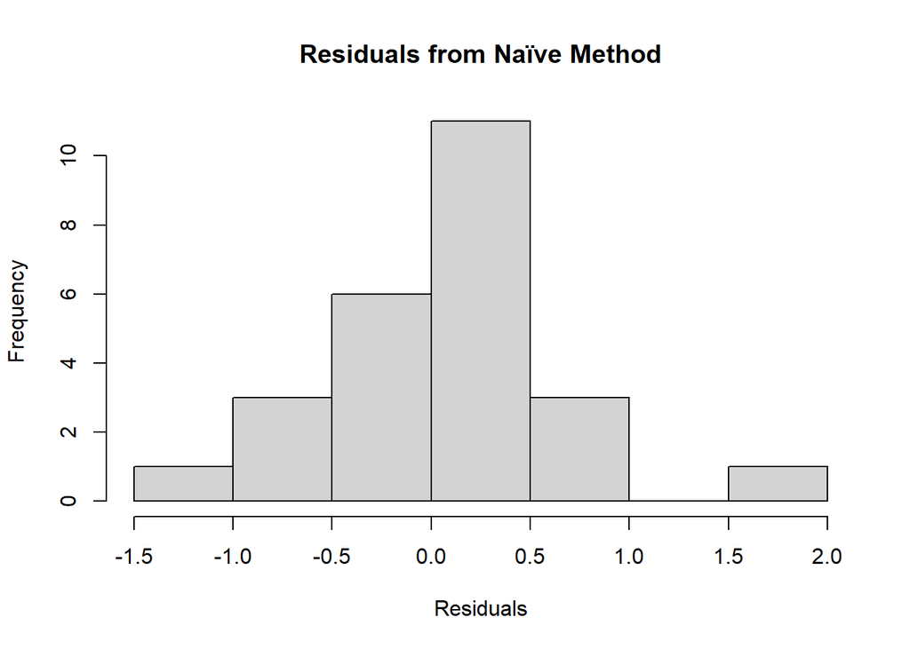

```r
hist(residuals(naiveForecast), main = "Residuals from Naïve Method", xlab = "Residuals")
```

The histogram shows that it is spread out around zero with some asymmetrical distribution. It is right skewed showing high frequency between 0 and 0.5.

#### Do a plot of fitted values vs. residuals. What does the plot indicate?

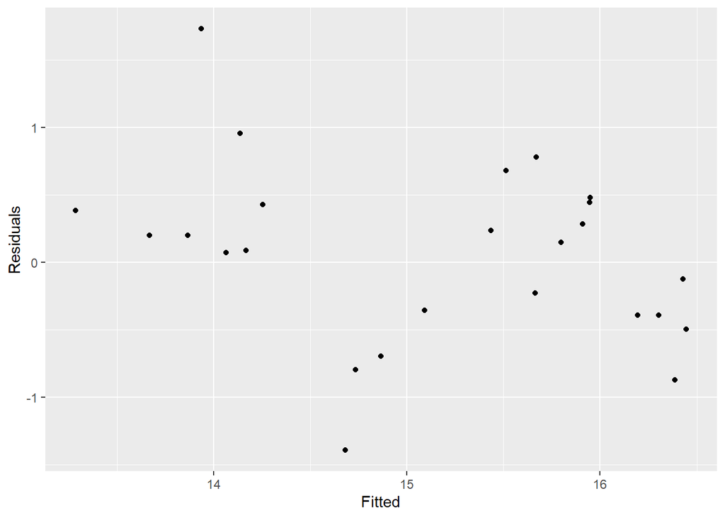

```r
cbind(Fitted = fitted(naiveForecast),
      Residuals=residuals(naiveForecast)) %>%
  as.data.frame() %>%
  ggplot(aes(x=Fitted, y=Residuals)) + geom_point()
```

The residual vs fitted graph shows irregular pattern suggesting that there’s randomness in the error. The variance of residuals is not consistant and doesnt follow any pattern.

#### Do a plot of actual values vs. residuals. What does the plot indicate?

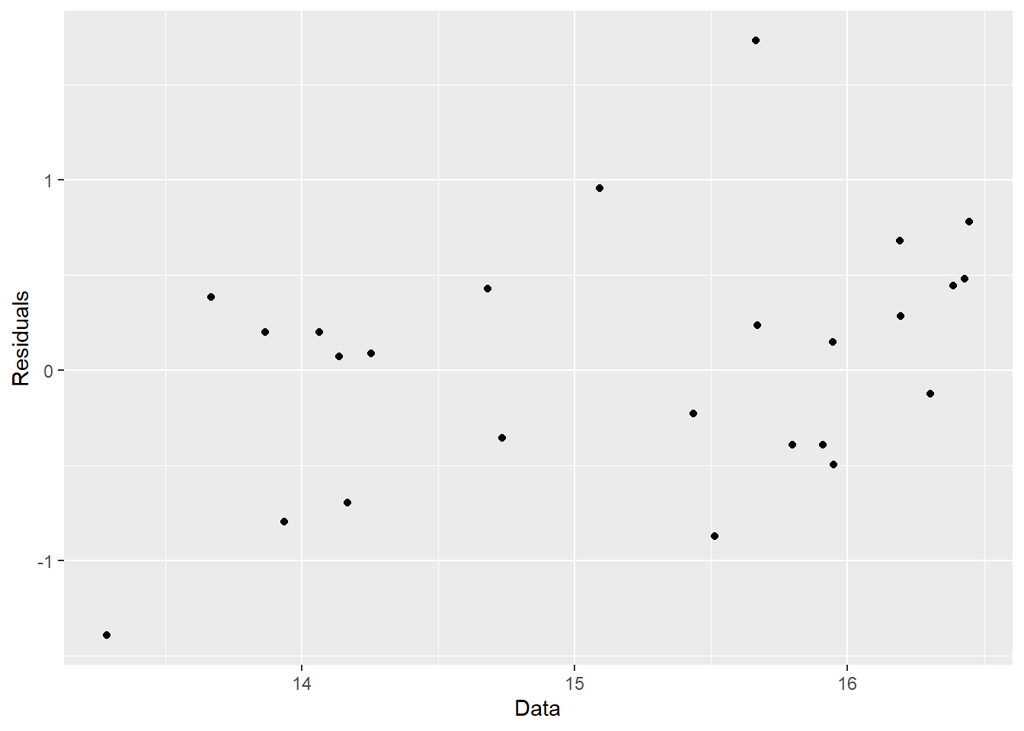

```r
cbind(Data=windowTS,
      Residuals=residuals(naiveForecast)) %>%
  as.data.frame() %>%
  ggplot(aes(x=Data, y=Residuals)) + geom_point()
```

The residual vs actual graph also shows irregular pattern suggesting that there’s randomness in the error like the previous graph. The variance of residuals is not consistant and doesnt follow any pattern.

#### Do an ACF plot of the residuals? What does this plot indicate?

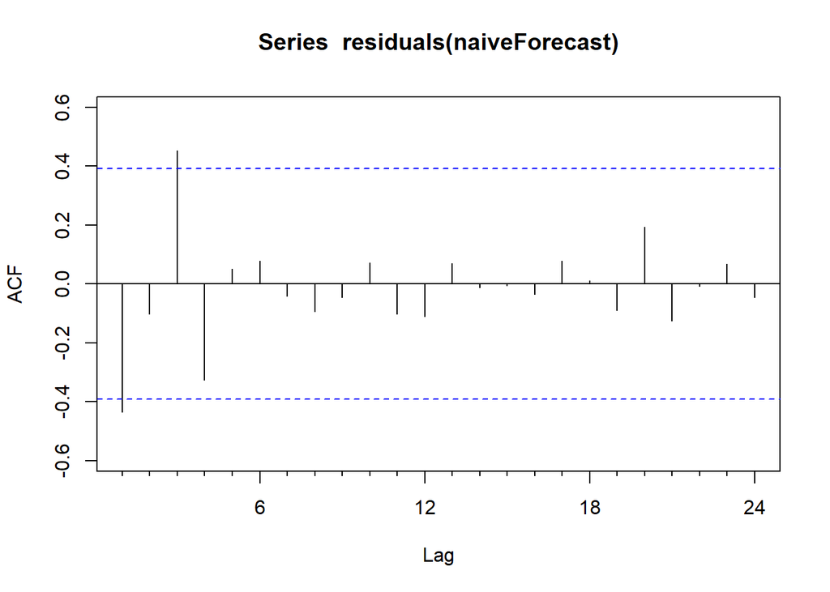

```r
Acf(residuals(naiveForecast))
```

#### Print the five measures of accuracy for this forecasting technique

```r
accuracy(naiveForecast)
```

```
##                 ME      RMSE     MAE       MPE     MAPE      MASE       ACF1
## Training set 0.053 0.6498938 0.51412 0.2460432 3.411387 0.3230122 -0.4356982
```

#### Forecast Time series value for next year. Show table and plot

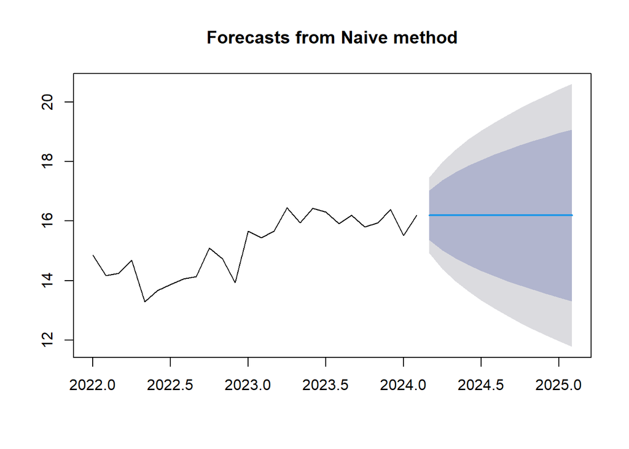

```r
nextYearNaive <- forecast(naiveForecast, h=12)
plot(nextYearNaive)
```

```r
print(nextYearNaive)
```

```
##          Point Forecast    Lo 80    Hi 80    Lo 95    Hi 95
## Mar 2024         16.191 15.35813 17.02387 14.91723 17.46477
## Apr 2024         16.191 15.01314 17.36886 14.38962 17.99238
## May 2024         16.191 14.74842 17.63358 13.98477 18.39723
## Jun 2024         16.191 14.52526 17.85674 13.64346 18.73854
## Jul 2024         16.191 14.32864 18.05336 13.34277 19.03923
## Aug 2024         16.191 14.15089 18.23111 13.07092 19.31108
## Sep 2024         16.191 13.98743 18.39457 12.82093 19.56107
## Oct 2024         16.191 13.83528 18.54672 12.58824 19.79376
## Nov 2024         16.191 13.69238 18.68962 12.36969 20.01231
## Dec 2024         16.191 13.55723 18.82477 12.16299 20.21901
## Jan 2025         16.191 13.42867 18.95333 11.96639 20.41561
## Feb 2025         16.191 13.30585 19.07615 11.77854 20.60346
```

#### Summarize this forecasting technique

Naive is a forcasting method where the future values are the same as last observed. The forecasting line is straight for next 12 months The forecasted value is 16.191 for every month.

#### How good is the accuracy?

RMSE is 0.65, indicating the average magnitude of prediction error is relatively low, suggesting good accuracy for the model

#### What does it predict the time series value will be in one year?

As it remains the same throughout the year, the forecasted value is 16.191 in next December 2024.

#### Other observation

The forecasted value remains constant at 16.191 across all months, suggesting the model may not capture seasonality well or assumes a stable trend.

# Simple Moving Averages

#Plot the graph for time series.

#• Show the Simple Moving average of order 3 on the plot above in Red

#• Show the Simple Moving average of order 6 on the plot above in Blue

#• Show the Simple Moving average of order 9 on the plot above in Green

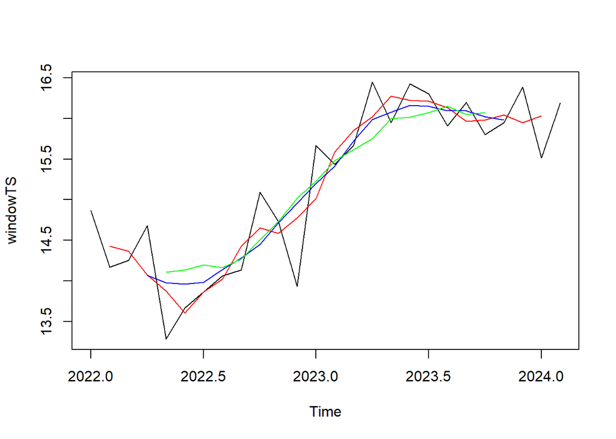

```r
#Moving Avg
MAforecast1 = ma(windowTS,order=3)
MAforecast2 = ma(windowTS,order=6)
MAforecast3 = ma(windowTS,order=9)

plot(windowTS)
lines(MAforecast1, col="red")
lines(MAforecast2, col="blue")
lines(MAforecast3, col="green")
```

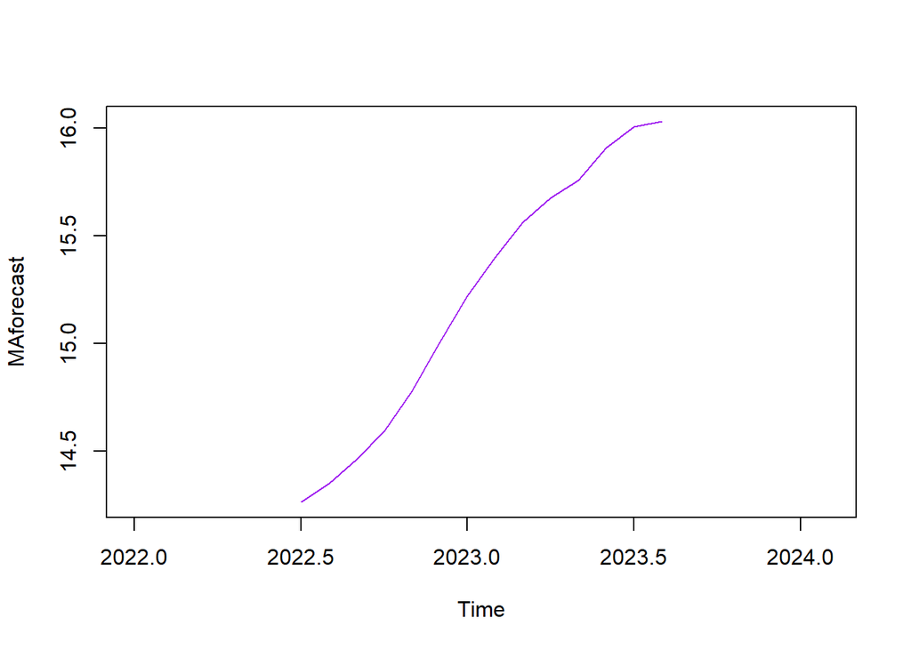

```r
MAforecast <- ma(windowTS,12)
plot(MAforecast)
lines(MAforecast, col="purple")
```

Simple moving averages of order 3 is closer to the actual time series. The other two smoothens out and doesnt capture the real data value.

#### (Bonus) show the forecast for the next 12 months using one of the simple average orders that you feel works best for time series

```r
MAforecast12 <- forecast(MAforecast2, h=12)
```

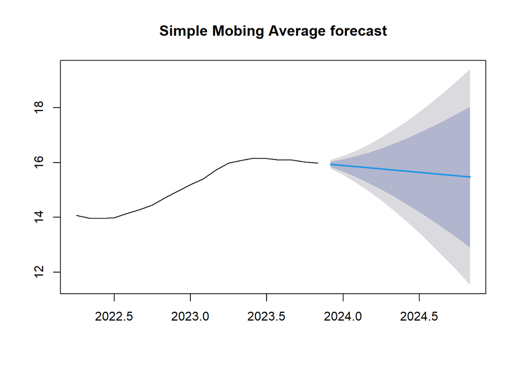

```r
plot(MAforecast12, main ='Simple Mobing Average forecast')
```

```r
summary(MAforecast12)
```

```
##
## Forecast method: ETS(M,A,N)
##
## Model Information:
## ETS(M,A,N)
##
## Call:
## ets(y = object, lambda = lambda, biasadj = biasadj, allow.multiplicative.trend = allow.multiplicative.trend)
##
##   Smoothing parameters:
##     alpha = 0.9999
##     beta  = 0.9999
##
##   Initial states:
##     l = 14.1629
##     b = -0.0891
##
##   sigma:  0.005
##
##       AIC      AICc       BIC
## -37.94030 -33.65458 -32.96163
##
## Error measures:
##                       ME       RMSE        MAE        MPE      MAPE       MASE
## Training set 0.002340272 0.06812097 0.05171541 0.02845714 0.3385603 0.02762252
##                    ACF1
## Training set 0.08423552
##
## Forecasts:
##          Point Forecast    Lo 80    Hi 80    Lo 95    Hi 95
## Dec 2023       15.93874 15.83702 16.04046 15.78317 16.09431
## Jan 2024       15.89648 15.66916 16.12379 15.54883 16.24413
## Feb 2024       15.85422 15.47408 16.23436 15.27284 16.43560
## Mar 2024       15.81196 15.25583 16.36809 14.96143 16.66249
## Apr 2024       15.76970 15.01716 16.52225 14.61878 16.92062
## May 2024       15.72744 14.76004 16.69484 14.24793 17.20696
## Jun 2024       15.68518 14.48599 16.88437 13.85118 17.51919
## Jul 2024       15.64292 14.19621 17.08964 13.43037 17.85548
## Aug 2024       15.60066 13.89168 17.30964 12.98700 18.21432
## Sep 2024       15.55840 13.57323 17.54358 12.52235 18.59446
## Oct 2024       15.51615 13.24156 17.79073 12.03746 18.99483
## Nov 2024       15.47389 12.89727 18.05051 11.53328 19.41449
```

#### What are your observations of the plot as the moving average order goes up?

According to our graphs we can see that as the order goes up the curve starts to smoothen out. The higher order averages are resulting in smooth curve. The blue line and green line are relatvely smoother than the red line and the purple line were the order is 12 is completely smoothen out.

# Simple Smoothing

#### Perform a simple smoothing forecast for the next 12 months for the time series.

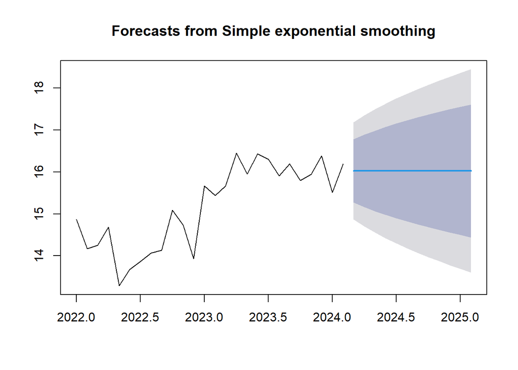

```r
sesForecast <- ses(windowTS, h=12)
plot(sesForecast)
```

```r
summary(sesForecast)
```

```
##
## Forecast method: Simple exponential smoothing
##
## Model Information:
## Simple exponential smoothing
##
## Call:
## ses(y = windowTS, h = 12)
##
##   Smoothing parameters:
##     alpha = 0.5558
##
##   Initial states:
##     l = 14.5655
##
##   sigma:  0.5893
##
##      AIC     AICc      BIC
## 61.13388 62.22479 64.90817
##
## Error measures:
##                     ME     RMSE       MAE      MPE     MAPE      MASE
## Training set 0.1009008 0.566215 0.4348547 0.555512 2.889828 0.2732112
##                    ACF1
## Training set -0.1227939
##
## Forecasts:
##          Point Forecast    Lo 80    Hi 80    Lo 95    Hi 95
## Mar 2024       16.02361 15.26835 16.77888 14.86854 17.17869
## Apr 2024       16.02361 15.15954 16.88769 14.70212 17.34510
## May 2024       16.02361 15.06297 16.98426 14.55444 17.49279
## Jun 2024       16.02361 14.97526 17.07196 14.42030 17.62693
## Jul 2024       16.02361 14.89434 17.15288 14.29655 17.75068
## Aug 2024       16.02361 14.81885 17.22837 14.18109 17.86614
## Sep 2024       16.02361 14.74781 17.29941 14.07245 17.97478
## Oct 2024       16.02361 14.68053 17.36669 13.96955 18.07768
## Nov 2024       16.02361 14.61646 17.43076 13.87156 18.17566
## Dec 2024       16.02361 14.55519 17.49204 13.77785 18.26938
## Jan 2025       16.02361 14.49637 17.55086 13.68789 18.35933
## Feb 2025       16.02361 14.43973 17.60750 13.60127 18.44595
```

#### What is the value of alpha? What does that value signify?

The value for aplha is 0.5558. it signifies coefficient for the level smoothing. It gives weightage to the recent data.

#### What is the value of the initial state?

The value for initial stage is 14.5655.

#### What is the value of sigma? What does the sigma signify?

The value of sigma is 0.5893. It represents the standard deviation of the errors.

## Perform Residual Analysis for this technique.

#### Do a plot of residuals. What does the plot indicate?

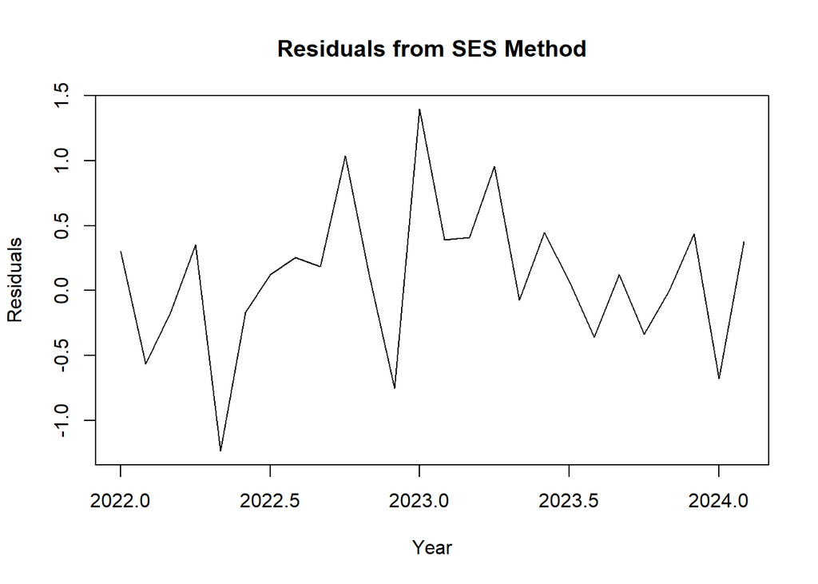

```r
plot(sesForecast$residuals , main = "Residuals from SES Method", ylab = "Residuals", xlab = "Year")
```

The residuals appear to fluctuate randomly around zero, which indicates that the SES model may have captured the overall trend or level in the data well.

#### Do a Histogram plot of residuals. What does the plot indicate?

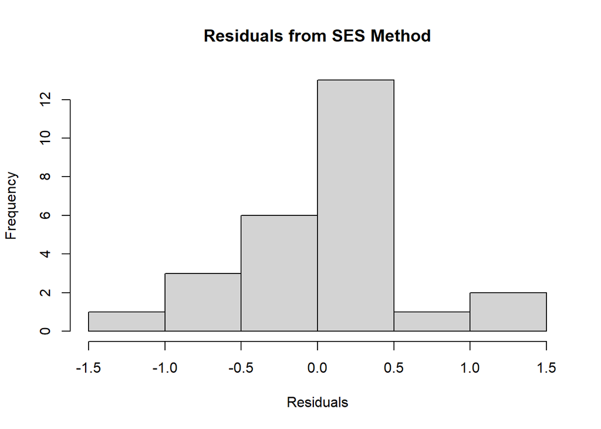

```r
hist(sesForecast$residuals, main = "Residuals from SES Method", xlab = "Residuals")
```

The historgam of residuals inidcate the residulas to be spread out around zero. The histogram shows assymetric distribution and is skewed towards right.

#### Do a plot of fitted values vs. residuals. What does the plot indicate?

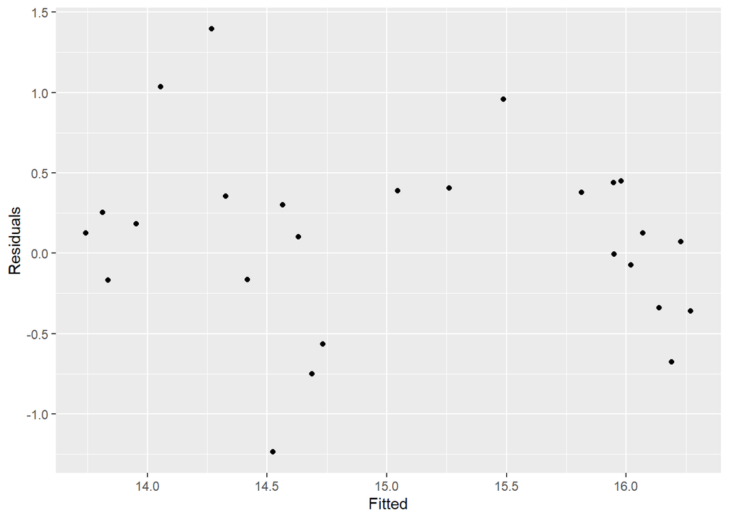

```r
cbind(Fitted = fitted(sesForecast),
      Residuals=residuals(sesForecast)) %>%
  as.data.frame() %>%
  ggplot(aes(x=Fitted, y=Residuals)) + geom_point()
```

The plot of fitted values vs. residuals shows no clear pattern, suggesting that the residuals are randomly distributed.

#### Do a plot of actual values vs. residuals. What does the plot indicate?

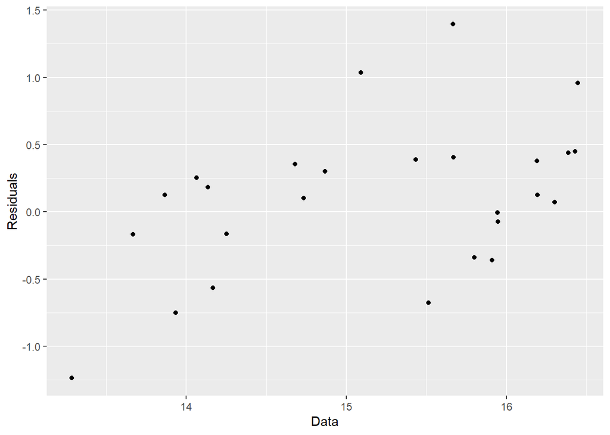

```r
cbind(Data = windowTS,
      Residuals=residuals(sesForecast)) %>%
  as.data.frame() %>%
  ggplot(aes(x=Data, y=Residuals)) + geom_point()
```

#### Do an ACF plot of the residuals? What does this plot indicate?

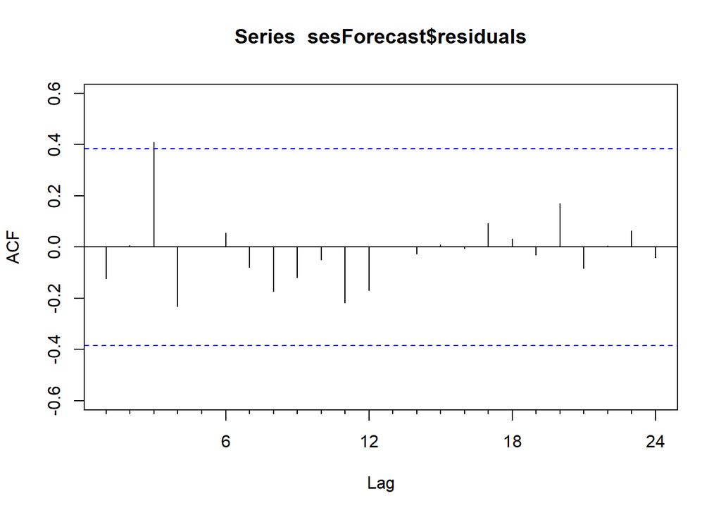

```r
Acf(sesForecast$residuals)
```

#### Print the five measures of accuracy for this forecasting technique

```r
accuracy(sesForecast)
```

```
##                     ME     RMSE       MAE      MPE     MAPE      MASE
## Training set 0.1009008 0.566215 0.4348547 0.555512 2.889828 0.2732112
##                    ACF1
## Training set -0.1227939
```

### Forecast

#### Time series value for next year. Show table and plot

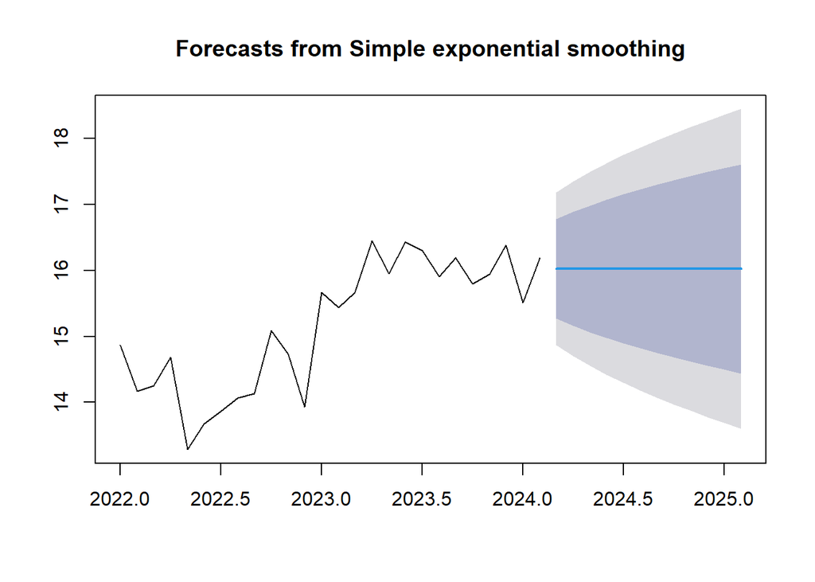

```r
sesFore <- forecast(sesForecast, h=12)
plot(sesFore)
```

```r
print(sesFore)
```

```
##          Point Forecast    Lo 80    Hi 80    Lo 95    Hi 95
## Mar 2024       16.02361 15.26835 16.77888 14.86854 17.17869
## Apr 2024       16.02361 15.15954 16.88769 14.70212 17.34510
## May 2024       16.02361 15.06297 16.98426 14.55444 17.49279
## Jun 2024       16.02361 14.97526 17.07196 14.42030 17.62693
## Jul 2024       16.02361 14.89434 17.15288 14.29655 17.75068
## Aug 2024       16.02361 14.81885 17.22837 14.18109 17.86614
## Sep 2024       16.02361 14.74781 17.29941 14.07245 17.97478
## Oct 2024       16.02361 14.68053 17.36669 13.96955 18.07768
## Nov 2024       16.02361 14.61646 17.43076 13.87156 18.17566
## Dec 2024       16.02361 14.55519 17.49204 13.77785 18.26938
## Jan 2025       16.02361 14.49637 17.55086 13.68789 18.35933
## Feb 2025       16.02361 14.43973 17.60750 13.60127 18.44595
```

#### Summarize this forecasting technique

Simple Exponential Smoothing predicts constant values for stable-level data with no trends or seasonality.

#### How good is the accuracy?

The model shows low errors with RMSE = 0.566 indicating good accuracy for the training set.

#### What does it predict the time series value will be in one year?

The time series value for Dec 2024 is predicted to be 16.02361.

# Holt-Winters

### Perform Holt-Winters forecast for the next 12 months for the time series.

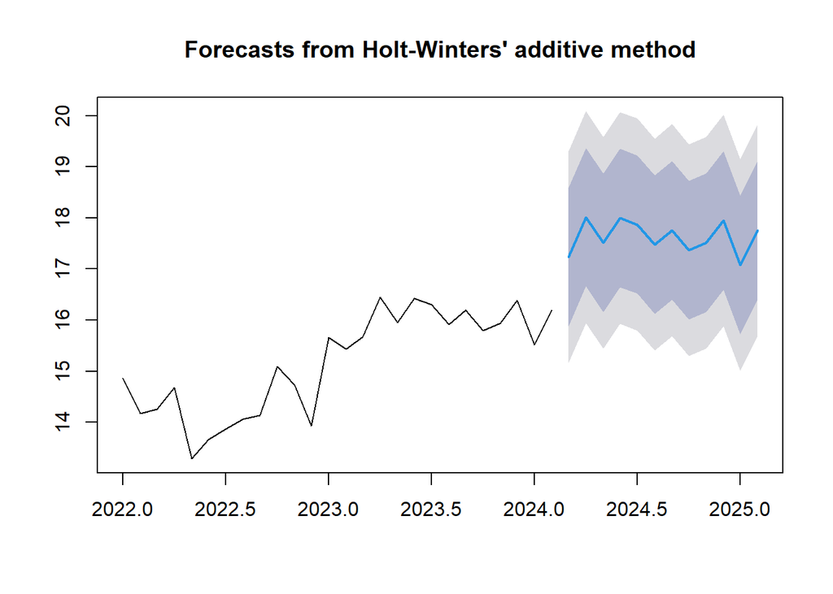

```r
hw_forecast <- hw(windowTS, h=12)
plot(hw_forecast)
```

```r
summary(hw_forecast)
```

```
##
## Forecast method: Holt-Winters' additive method
##
## Model Information:
## Holt-Winters' additive method
##
## Call:
## hw(y = windowTS, h = 12)
##
##   Smoothing parameters:
##     alpha = 2e-04
##     beta  = 2e-04
##     gamma = 0.9997
##
##   Initial states:
##     l = 13.424
##     b = 0.1305
##     s = -0.9951 -0.2147 0.5375 -0.7997 -0.2747 -0.8722
##            0.2528 -1.0152 0.5749 0.2429 0.6483 1.9153
##
##   sigma:  1.0571
##
##       AIC      AICc       BIC
##  96.75263 173.25263 118.14027
##
## Error measures:
##                       ME     RMSE       MAE        MPE     MAPE      MASE
## Training set -0.01760396 0.655559 0.5118556 -0.1586194 3.307403 0.3215895
##                   ACF1
## Training set 0.1938631
##
## Forecasts:
##          Point Forecast    Lo 80    Hi 80    Lo 95    Hi 95
## Mar 2024       17.23629 15.88162 18.59096 15.16450 19.30809
## Apr 2024       18.01447 16.65980 19.36914 15.94268 20.08626
## May 2024       17.51639 16.16172 18.87107 15.44460 19.58819
## Jun 2024       17.99612 16.64145 19.35080 15.92433 20.06792
## Jul 2024       17.86972 16.51505 19.22440 15.79792 19.94152
## Aug 2024       17.47630 16.12162 18.83097 15.40450 19.54809
## Sep 2024       17.75974 16.40506 19.11441 15.68794 19.83154
## Oct 2024       17.36545 16.01077 18.72013 15.29365 19.43725
## Nov 2024       17.51113 16.15645 18.86581 15.43932 19.58293
## Dec 2024       17.95157 16.59689 19.30626 15.87976 20.02338
## Jan 2025       17.07859 15.72390 18.43328 15.00678 19.15040
## Feb 2025       17.75657 16.40188 19.11126 15.68475 19.82839
```

#### What is the value of alpha? What does that value signify?

alpha is 0.0002, which signifies the weight given to the most recent observation

#### What is the value of beta? What does that value signify?

beta is 0.0002, which determines the weight given to the trend component

#### What is the value of gamma? What does that value signify?

gamma is 0.9997, which signifies the weight given to the seasonal component

#### What is the value of initial states for the level, trend, and seasonality? What dothese values signify?

Level is 13.424. It represents the initial smoothed level of the time series at the starting point. Trend is b = 0.1305. It is the initial value of the trend component, indicating the initial direction or slope of the time series. Seasonality is s = -0.9951, -0.2147, 0.5375, -0.7997, -0.2747, -0.8722, 0.2528, -1.0152, 0.5749, 0.2429, 0.6483, 1.9153. These are the initial seasonal factors, which capture repeating seasonal patterns over the time series.

#### What is the value of sigma? What does the sigma signify?

sigma is 1.0571 which represents the standard deviation of the residuals

### Perform Residual Analysis for this technique.

#### Do a plot of residuals. What does the plot indicate?

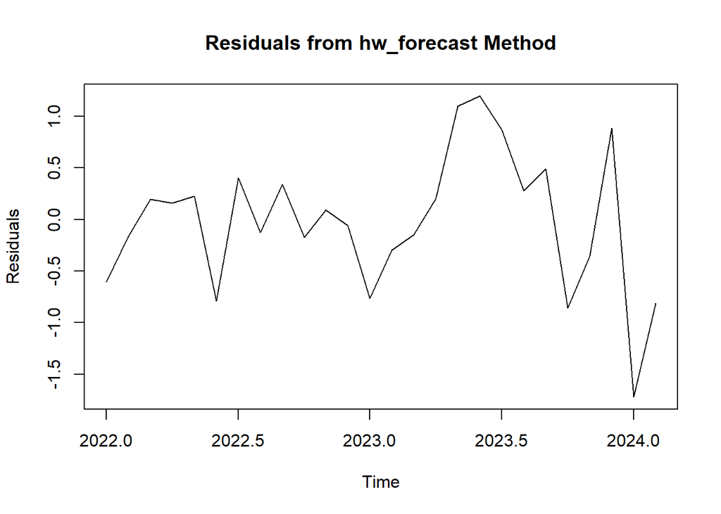

```r
plot(hw_forecast$residuals , main = "Residuals from hw_forecast Method",
     ylab = "Residuals",
     xlab = "Time")
```

The residuals appear to fluctuate randomly around zero, which indicates that the Holts Winter model may have captured the overall trend or level in the data well.

#### Do a Histogram plot of residuals. What does the plot indicate?

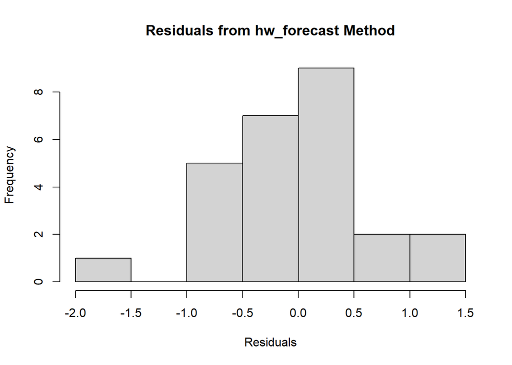

```r
hist(hw_forecast$residuals, main = "Residuals from hw_forecast Method",
     xlab = "Residuals")
```

#### Do a plot of fitted values vs. residuals. What does the plot indicate?

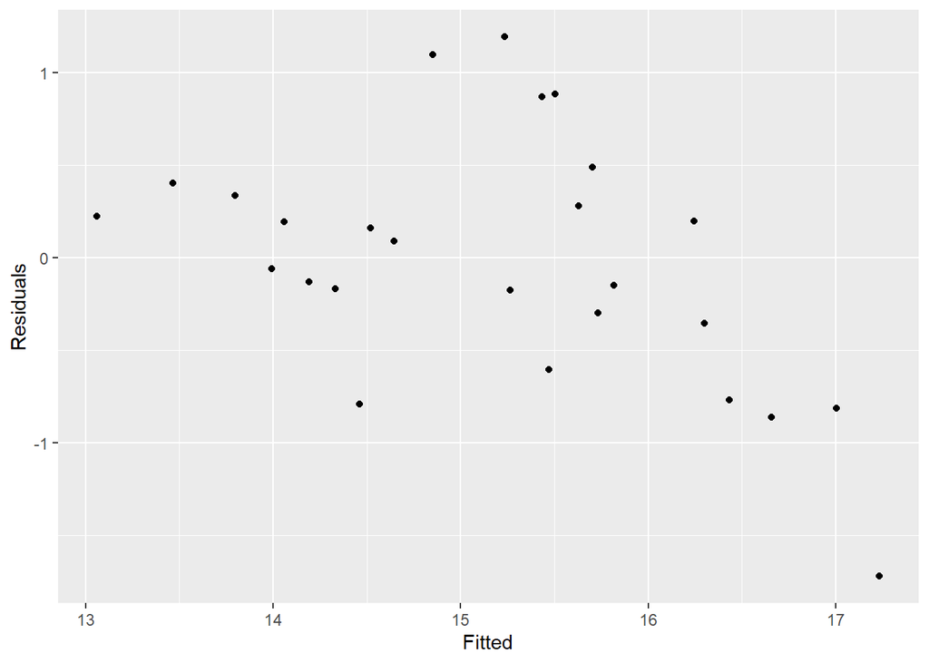

```r
cbind(Fitted = fitted(hw_forecast),
      Residuals=residuals(hw_forecast)) %>%
  as.data.frame() %>%
  ggplot(aes(x=Fitted, y=Residuals)) + geom_point()
```

#### Do a plot of actual values vs. residuals. What does the plot indicate?

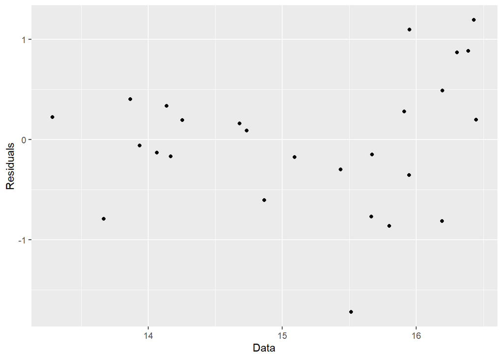

```r
cbind(Data = windowTS,
      Residuals=residuals(hw_forecast)) %>%
  as.data.frame() %>%
  ggplot(aes(x=Data, y=Residuals)) + geom_point()
```

like the previousplot, the plot of actual values vs. residuals shows no clear pattern, suggesting that the residuals are randomly distributed. #### Do an ACF plot of the residuals? What does this plot indicate?

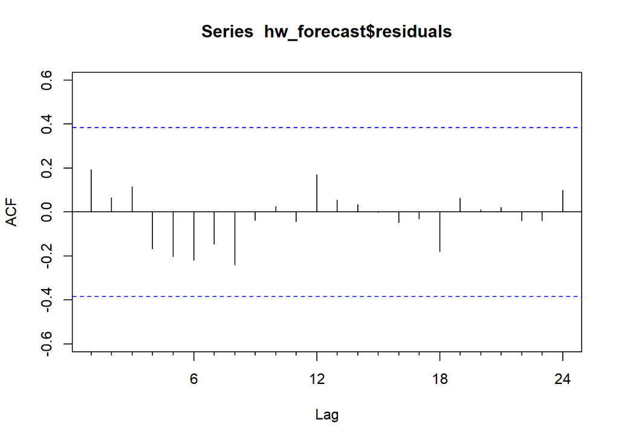

```r
Acf(hw_forecast$residuals)
```

All autocorrelations fall within the blue confidence bounds, indicating no significant autocorrelation in the residuals.The lack of significant lags suggests the HoltsWinter model adequately captures the structure of the data.

### Print the five measures of accuracy for this forecasting technique

```r
accuracy(hw_forecast)
```

```
##                       ME     RMSE       MAE        MPE     MAPE      MASE
## Training set -0.01760396 0.655559 0.5118556 -0.1586194 3.307403 0.3215895
##                   ACF1
## Training set 0.1938631
```

### Forecast

#### Time series value for next year. Show table and plot

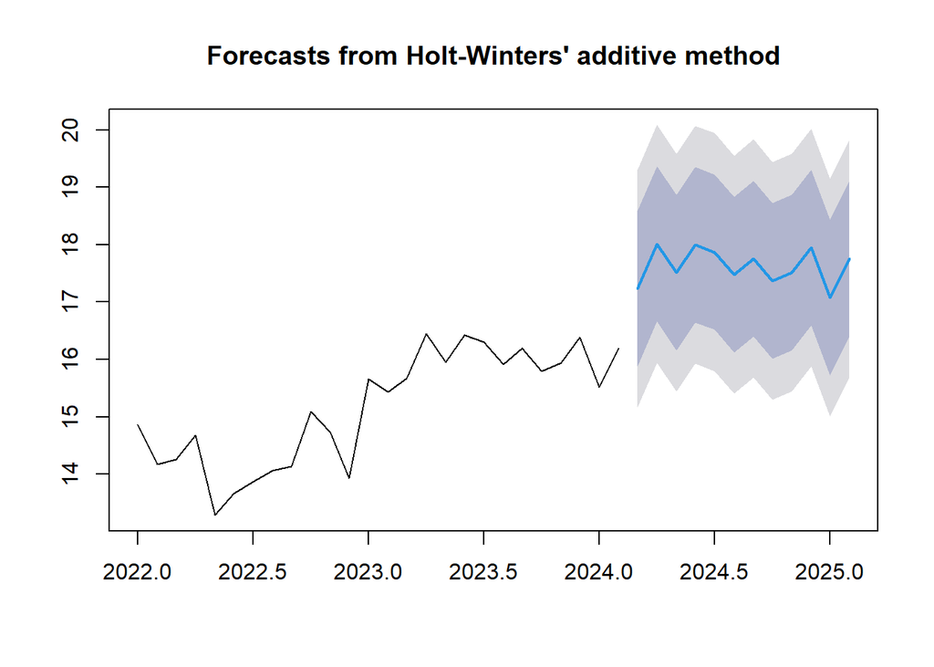

```r
hw_fore <- forecast(hw_forecast, h=12)
plot(hw_fore)
```

```r
print(hw_fore)
```

```
##          Point Forecast    Lo 80    Hi 80    Lo 95    Hi 95
## Mar 2024       17.23629 15.88162 18.59096 15.16450 19.30809
## Apr 2024       18.01447 16.65980 19.36914 15.94268 20.08626
## May 2024       17.51639 16.16172 18.87107 15.44460 19.58819
## Jun 2024       17.99612 16.64145 19.35080 15.92433 20.06792
## Jul 2024       17.86972 16.51505 19.22440 15.79792 19.94152
## Aug 2024       17.47630 16.12162 18.83097 15.40450 19.54809
## Sep 2024       17.75974 16.40506 19.11441 15.68794 19.83154
## Oct 2024       17.36545 16.01077 18.72013 15.29365 19.43725
## Nov 2024       17.51113 16.15645 18.86581 15.43932 19.58293
## Dec 2024       17.95157 16.59689 19.30626 15.87976 20.02338
## Jan 2025       17.07859 15.72390 18.43328 15.00678 19.15040
## Feb 2025       17.75657 16.40188 19.11126 15.68475 19.82839
```

### Summarize this forecasting technique

The HoltsWinter model uses time series forecasting with trend and seasonality components to predict future values.

#### How good is the accuracy?

The model has good accuracy with RMSE = 0.656

#### What does it predict the time series value will be in one year?

The forecast predicts 17.95157 in December 2024.

#### Other observation

The RMSE value of 0.656 indicates that while the forecast is accurate,and residuals show minimal autocorrelation

#ARIMA

#• Is Time Series data Stationary? How did you verify?

No, the time series data is not stationary. The time series plot reveal trends and seasonality, confirming non-stationarity.

#• How many differences are needed to make it stationary?

n=1 which indicates 1 difference is required to make the time series stationary.

#• Is Seasonality component needed?

#• Plot the Time Series chart of the differenced series.

```r
ndiffs(windowTS)
```

```
## [1] 1
```

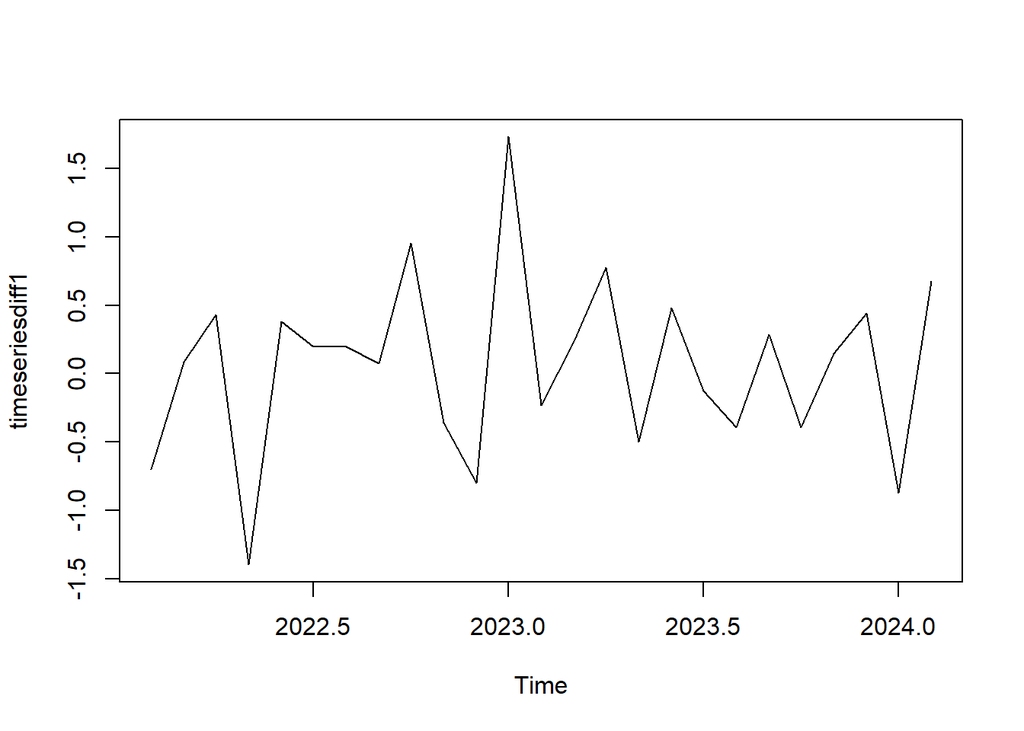

```r
timeseriesdiff1 <- diff(windowTS, differences=1)
plot(timeseriesdiff1)
```

#• Plot the ACF and PACF plot of the differenced series.

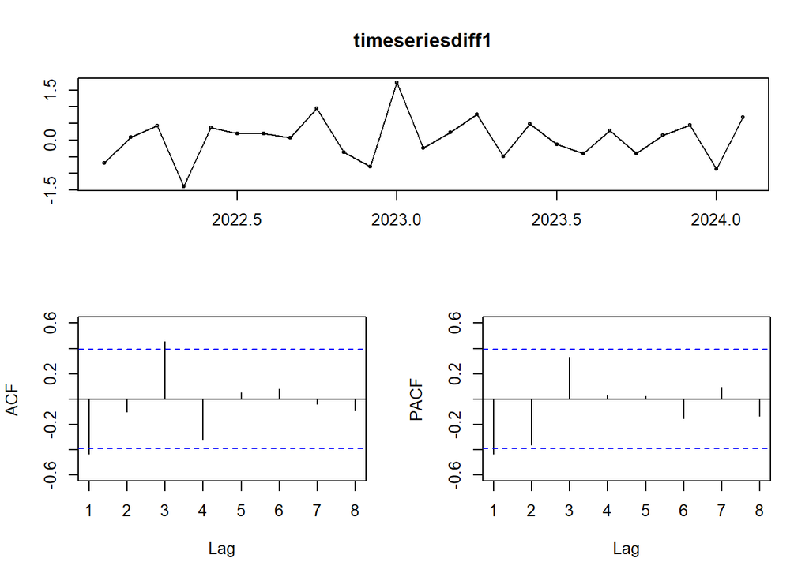

```r
tsdisplay(timeseriesdiff1)
```

#• Based on the ACF and PACF, which are the possible ARIMA model possible?

```r
auto_fit <- auto.arima(windowTS, trace=TRUE, stepwise = FALSE,approximation = FALSE)
```

```
##
##  ARIMA(0,1,0)                               : 51.57352
##  ARIMA(0,1,0)            with drift         : 53.77824
##  ARIMA(0,1,1)                               : 48.24721
##  ARIMA(0,1,1)            with drift         : 49.88389
##  ARIMA(0,1,2)                               : 48.51251
##  ARIMA(0,1,2)            with drift         : 50.95166
##  ARIMA(0,1,3)                               : 50.25856
##  ARIMA(0,1,3)            with drift         : 53.11982
##  ARIMA(0,1,4)                               : Inf
##  ARIMA(0,1,4)            with drift         : Inf
##  ARIMA(0,1,5)                               : Inf
##  ARIMA(0,1,5)            with drift         : Inf
##  ARIMA(1,1,0)                               : 48.62806
##  ARIMA(1,1,0)            with drift         : 50.76726
##  ARIMA(1,1,1)                               : 50.17333
##  ARIMA(1,1,1)            with drift         : 52.19397
##  ARIMA(1,1,2)                               : 51.28083
##  ARIMA(1,1,2)            with drift         : 54.071
##  ARIMA(1,1,3)                               : Inf
##  ARIMA(1,1,3)            with drift         : Inf
##  ARIMA(1,1,4)                               : Inf
##  ARIMA(1,1,4)            with drift         : Inf
##  ARIMA(2,1,0)                               : 48.20508
##  ARIMA(2,1,0)            with drift         : 49.80281
##  ARIMA(2,1,1)                               : Inf
##  ARIMA(2,1,1)            with drift         : Inf
##  ARIMA(2,1,2)                               : 49.31717
##  ARIMA(2,1,2)            with drift         : 52.19999
##  ARIMA(2,1,3)                               : Inf
##  ARIMA(2,1,3)            with drift         : Inf
##  ARIMA(3,1,0)                               : 46.77066
##  ARIMA(3,1,0)            with drift         : 49.42144
##  ARIMA(3,1,1)                               : 49.90649
##  ARIMA(3,1,1)            with drift         : 52.80319
##  ARIMA(3,1,2)                               : Inf
##  ARIMA(3,1,2)            with drift         : Inf
##  ARIMA(4,1,0)                               : 49.90939
##  ARIMA(4,1,0)            with drift         : 52.80723
##  ARIMA(4,1,1)                               : 53.4198
##  ARIMA(4,1,1)            with drift         : Inf
##  ARIMA(5,1,0)                               : 53.41251
##  ARIMA(5,1,0)            with drift         : 56.69595
##
##
##
##  Best model: ARIMA(3,1,0)
```

#• Show the AIC, BIC and Sigma^2 for the possible models?

```r
auto_fit
```

```
## Series: windowTS
## ARIMA(3,1,0)
##
## Coefficients:
##           ar1      ar2     ar3
##       -0.4560  -0.1214  0.4010
## s.e.   0.1811   0.1998  0.1803
##
## sigma^2 = 0.278:  log likelihood = -18.39
## AIC=44.77   AICc=46.77   BIC=49.65
```

sigma^2 = 0.278 AIC=44.77 BIC=49.65 for the best ARIMA model ARIMA(3,1,0).

#• Based on the above AIC, BIC and Sigma^2 values, which model will you select?

since the lowest AIC, AICc, and BIC values as compared to alternative models and the sigma^2 is acceptably small, ARIMA(3,1,0) is the best model

#• What is the final formula for ARIMA with the coefficients?

```r
coefficients <- coef(auto_fit)
print(coefficients)
```

```
##        ar1        ar2        ar3
## -0.4560166 -0.1213601  0.4009509
```

#• Perform Residual Analysis for this technique.

#o Do a plot of residuals. What does the plot indicate?

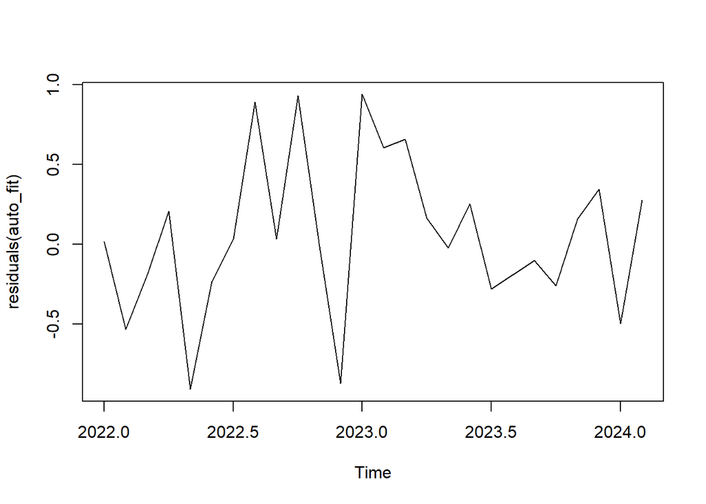

```r
plot.ts(residuals(auto_fit))
```

Residuals doest appear to have a trend, seasonality, or a repeating pattern, it suggests the model has captured the data well.

#o Do a Histogram plot of residuals. What does the plot indicate?

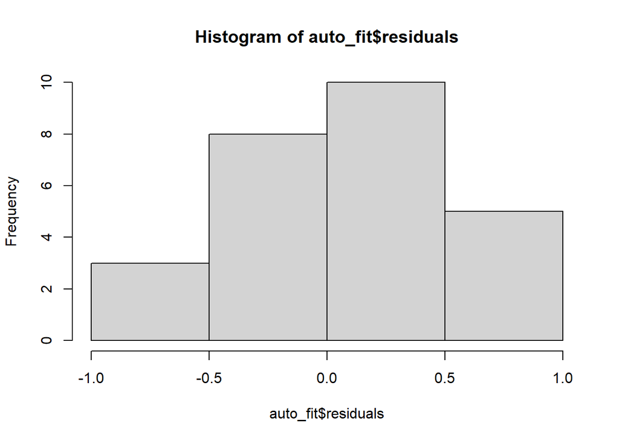

```r
hist(auto_fit$residuals)
```

#o Do a plot of fitted values vs. residuals. What does the plot indicate?

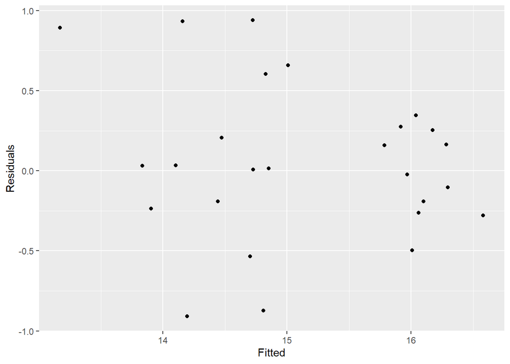

```r
cbind(Fitted = fitted(auto_fit),
      Residuals=residuals(auto_fit)) %>%
  as.data.frame() %>%
  ggplot(aes(x=Fitted, y=Residuals)) + geom_point()
```

The plot of fitted values vs. residuals shows no clear pattern, suggesting that the residuals are randomly distributed, this indicates the model fits the data well. #o Do a plot of actual values vs. residuals. What does the plot indicate?

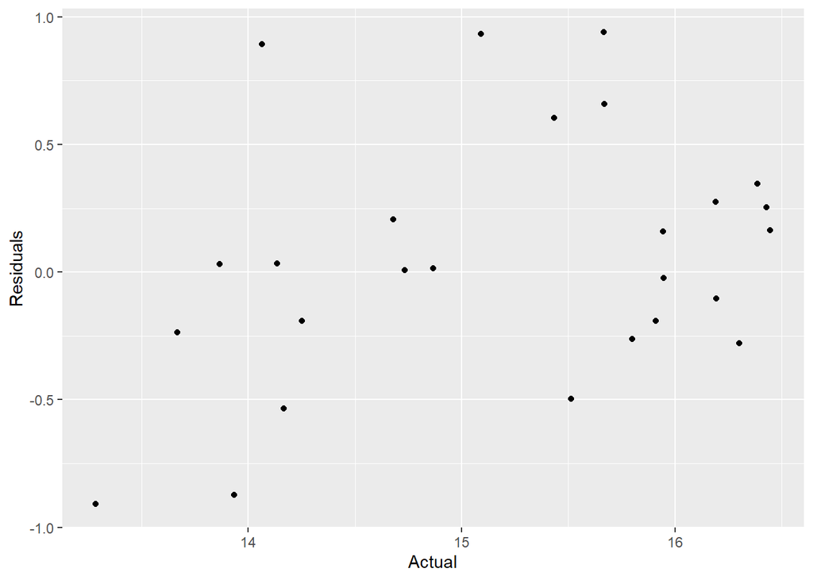

```r
cbind(Actual = windowTS,
      Residuals=residuals(auto_fit)) %>%
  as.data.frame() %>%
  ggplot(aes(x=Actual, y=Residuals)) + geom_point()
```

Similar to above graph, The plot of actual values vs. residuals shows no clear pattern, suggesting that the residuals are randomly distributed, this indicates the model fits the data well.

#o Do an ACF plot of the residuals? What does this plot indicate?

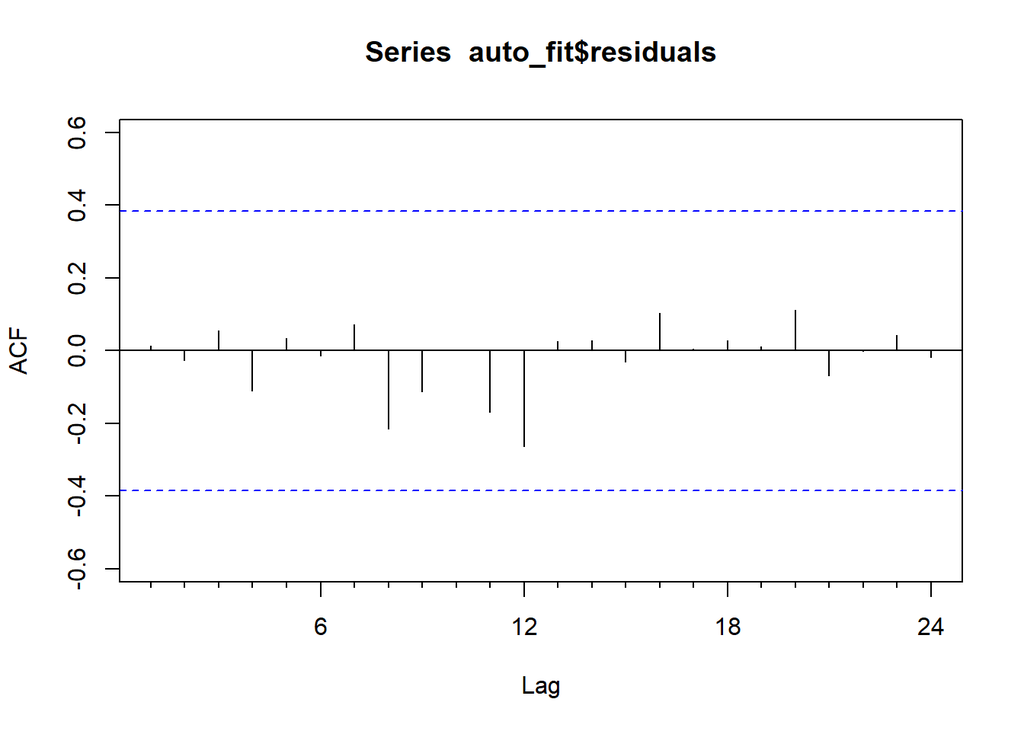

```r
Acf(auto_fit$residuals)
```

All bars fall within the blue confidence bounds, it suggests that the residuals are random, meaning the model has successfully captured all patterns in the data.

#• Print the 5 measures of accuracy for this forecasting technique.

```r
accuracy(auto_fit)
```

```
##                      ME      RMSE      MAE       MPE     MAPE      MASE
## Training set 0.05453538 0.4850027 0.369875 0.2882758 2.481099 0.2323857
##                    ACF1
## Training set 0.01221806
```

#• Forecast #o Next one year. Show table and plot

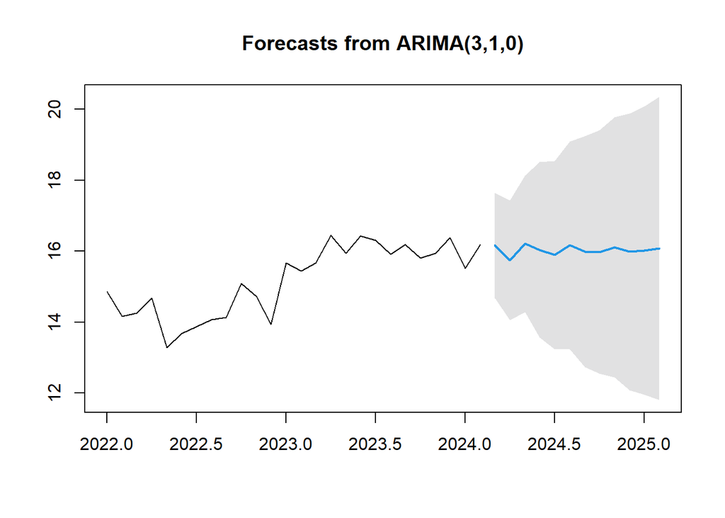

```r
next12<-forecast(auto_fit,h=12,level=c(99.5))
plot(next12)
```

```r
print(next12)
```

```
##          Point Forecast  Lo 99.5  Hi 99.5
## Mar 2024       16.16459 14.68457 17.64461
## Apr 2024       15.74432 14.05949 17.42915
## May 2024       16.21102 14.28498 18.13706
## Jun 2024       16.03861 13.56625 18.51097
## Jul 2024       15.89209 13.23159 18.55258
## Aug 2024       16.16695 13.24092 19.09298
## Sep 2024       15.99026 12.73486 19.24566
## Oct 2024       15.97873 12.55026 19.40720
## Nov 2024       16.11564 12.44729 19.78398
## Dec 2024       15.98376 12.08291 19.88462
## Jan 2025       16.02266 11.95640 20.08892
## Feb 2025       16.07582 11.80109 20.35055
```

#o Next two years. Show table and plot

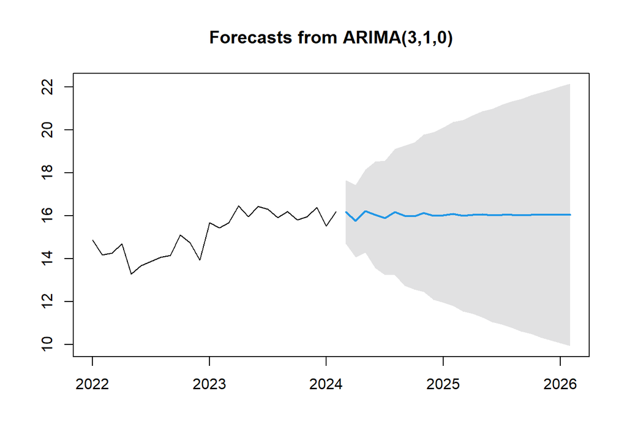

```r
next24<-forecast(auto_fit,h=24,level=c(99.5))
plot(next24)
```

```r
print(next24)
```

```
##          Point Forecast   Lo 99.5  Hi 99.5
## Mar 2024       16.16459 14.684569 17.64461
## Apr 2024       15.74432 14.059491 17.42915
## May 2024       16.21102 14.284980 18.13706
## Jun 2024       16.03861 13.566249 18.51097
## Jul 2024       15.89209 13.231594 18.55258
## Aug 2024       16.16695 13.240918 19.09298
## Sep 2024       15.99026 12.734860 19.24566
## Oct 2024       15.97873 12.550258 19.40720
## Nov 2024       16.11564 12.447293 19.78398
## Dec 2024       15.98376 12.082907 19.88462
## Jan 2025       16.02266 11.956401 20.08892
## Feb 2025       16.07582 11.801086 20.35055
## Mar 2025       15.99398 11.534217 20.45375
## Apr 2025       16.04045 11.421921 20.65897
## May 2025       16.05050 11.250607 20.85040
## Jun 2025       16.00746 11.047970 20.96696
## Jul 2025       16.04450 10.933880 21.15512
## Aug 2025       16.03687 10.765943 21.30779
## Sep 2025       16.01860 10.603225 21.43397
## Oct 2025       16.04270 10.484597 21.60081
## Nov 2025       16.03087 10.328225 21.73351
## Dec 2025       16.02601 10.189153 21.86288
## Jan 2026       16.03933 10.068131 22.01053
## Feb 2026       16.02910  9.925136 22.13307
```

#• Summarize this forecasting technique

ARIMA-based forecasting predicts future values of the time series, with confidence intervals provided at a 99.5% level.

#o How good is the accuracy?

The accuracy metrics, indicate good performance with RMSE = 0.485, and minimal residuals

#o What does it predict time series will be in one year and next two years?

In one year and two year, the model forecasts a range of approximately 16.16 in March 2024 to 15.98 in December 2024.

#o Other observation

The model performs well with random residuals. The forecast intervals widen gradually, capturing increasing uncertainty over time.

# Accuracy Summary

#### Show a table of all the forecast methods above with their accuracy measures.

```r
accuracy_naive <- accuracy(naiveForecast)
accuracy_ses <- accuracy(sesForecast)
accuracy_hw <- accuracy(hw_forecast)
accuracy_arima <- accuracy(auto_fit)


accuracy_table <- data.frame(
  Model = c("Naive", "SES", "Holt-Winters", "ARIMA"),
  ME = c(accuracy_naive["Training set", "ME"],  accuracy_ses["Training set", "ME"], accuracy_hw["Training set", "ME"],accuracy_arima["Training set", "ME"]),
  MAE = c(accuracy_naive["Training set", "MAE"],  accuracy_ses["Training set", "MAE"], accuracy_hw["Training set", "MAE"],accuracy_arima["Training set", "MAE"]),
  MASE = c(accuracy_naive["Training set", "MASE"],  accuracy_ses["Training set", "MASE"], accuracy_hw["Training set", "MASE"],accuracy_arima["Training set", "MASE"]),
  RMSE = c(accuracy_naive["Training set", "RMSE"],  accuracy_ses["Training set", "RMSE"], accuracy_hw["Training set", "RMSE"],accuracy_arima["Training set", "RMSE"]),
  MAPE = c(accuracy_naive["Training set", "MAPE"],  accuracy_ses["Training set", "MAPE"], accuracy_hw["Training set", "MAPE"],accuracy_arima["Training set", "MAPE"]))

accuracy_table
```

```
##          Model          ME       MAE      MASE      RMSE     MAPE
## 1        Naive  0.05300000 0.5141200 0.3230122 0.6498938 3.411387
## 2          SES  0.10090076 0.4348547 0.2732112 0.5662150 2.889828
## 3 Holt-Winters -0.01760396 0.5118556 0.3215895 0.6555590 3.307403
## 4        ARIMA  0.05453538 0.3698750 0.2323857 0.4850027 2.481099
```

#### Separately define each forecast method and why it is useful. Show the best and worst forecast method for each of the accuracy measures.

Naive Method: Assumes the most recent observed value is the best predictor of the next value.It’s simple to implement and serves as a baseline for evaluating other forecasting models.

Simple Exponential Smoothing:It averages past data with exponentially decreasing weights to emphasize recent observations.It’s effective for time series with no trend or seasonality.

Holt-Winters Method: It extends SES by incorporating components for trend and seasonality and is suitable for time series with trend and seasonal patterns.

ARIMA: It combines autoregressive, differencing, and moving average components to model both trend and seasonality.It’s a versatile model that handles complex time series with autocorrelation and non-stationarity.

Best and worst forecast measure for each accuracy measure is: For ME best is Holt-Winters and worst is SES. For MAE best is ARIMA and worst is Naive. For MASE best is ARIMA and worst is Naive. For RMSE best is ARIMA and worst is Holt-Winters. For MAPE best is ARIMA and worst is Naive.

# Conclusion

#### Summarize your analysis of time series value over the time period.

The time series exhibits moderate fluctuations over the analyzed period, with no strong seasonal patterns but a noticeable trend.

#### Based on your analysis and forecast above, do you think the value of the time series will increase, decrease, or stay flat over the next year? How about the next 2 years?

The forecast suggests the time series value will slightly increase or remain stable in next one year. Over the two-years, the value is expected to follow a similar trend with modest fluctuations.

#### Rank forecasting methods for this time series based on historical values.

```r
accuracy_table$Model_Rank <- rank(accuracy_table$RMSE)
print(accuracy_table)
```

```
##          Model          ME       MAE      MASE      RMSE     MAPE Model_Rank
## 1        Naive  0.05300000 0.5141200 0.3230122 0.6498938 3.411387          3
## 2          SES  0.10090076 0.4348547 0.2732112 0.5662150 2.889828          2
## 3 Holt-Winters -0.01760396 0.5118556 0.3215895 0.6555590 3.307403          4
## 4        ARIMA  0.05453538 0.3698750 0.2323857 0.4850027 2.481099          1
```

ARIMA ranks top with lowest RMSE, followed by Simple Exponential Smoothing, then Naive and then Holts winter.